# Check interior point method

Matthew Stephens

2015-11-18

**Last updated:** 2017-01-15

**Code version:** 94a3347615361216b39b8a9333bfa8354794e0ff

Here we compare the likelihoods achieved by the newly implemented interior point method against the EM algorithm.

**Note:** the last code chunk (“compare_lfsr”) may take several minutes to render in R or RStudio because it uses ggplot to plot more than a million data points. Also, it it may not be possible to run the last code chunk interactively in RStudio.

First, we load the necessary libraries.

```r
library(ggplot2)
library(dplyr)
library(reshape2)
```

## Log-likelihood comparison

The ‘dsc-opt’ script simply runs both methods (IP and EM) on the same data sets, and compares the difference in the log-likelihoods. We can see that in >90% of cases the difference is negligible. Then there is a tail of cases where the IP log-likelihood is higher - presumably where the EM doesn’t really converge so well.

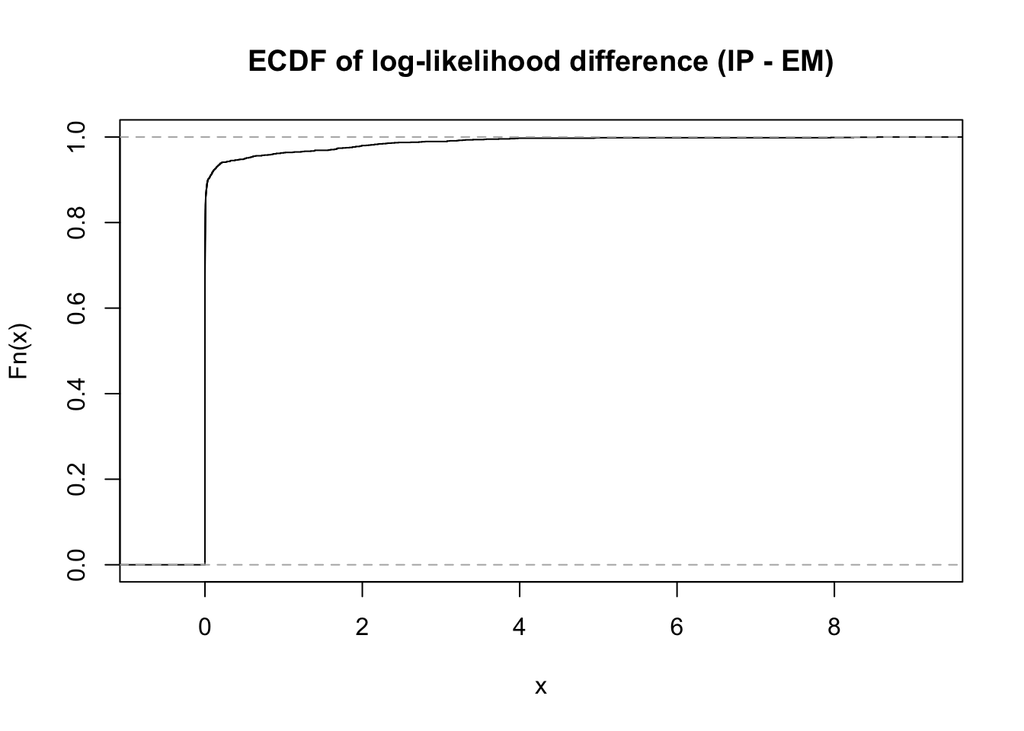

```r
load("../output/dsc-opt-files/dsc_opt.RData")
plot(ecdf(dsc_opt$res$diff1),
     main = "ECDF of log-likelihood difference (IP - EM)")
```

## lfsr comparison

However, what we really care about is inference quantities, such as the lfsr, rather than the log-likelihood. Here we compare the lfsr for the simulations where we ran both the IP method and EM method (nocxx) in dsc-shrink.

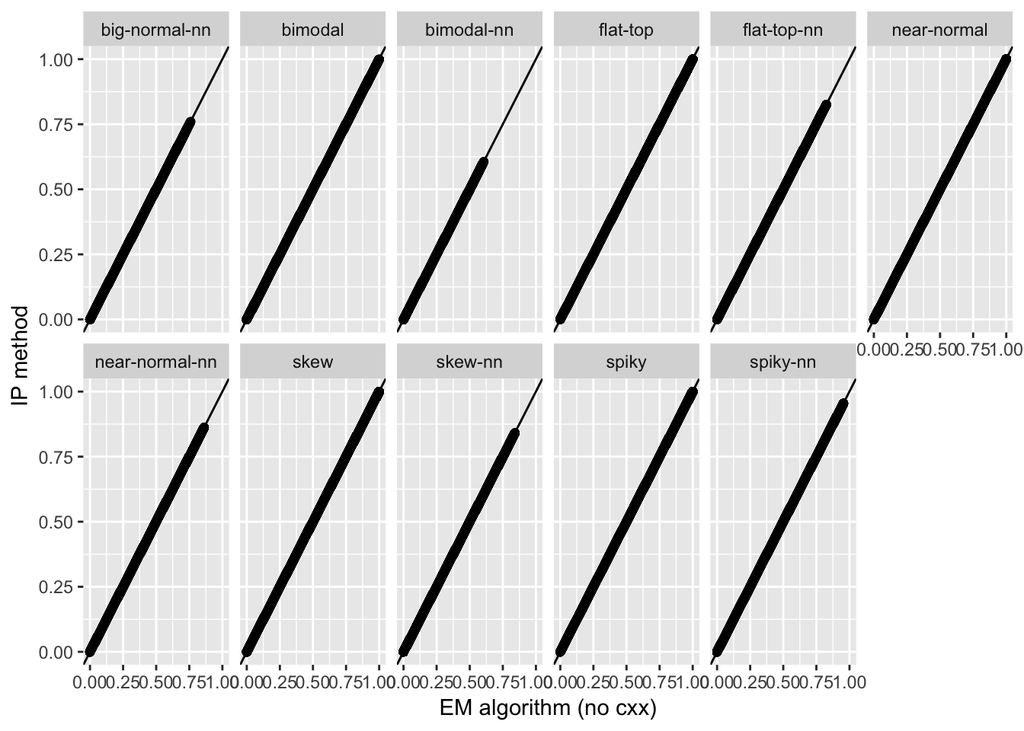

```r
load("../output/dsc-shrink-files/res.RData")

# Select out the lfsr estimates for each method.
df1 = res$lfsr %>% filter(method %in% c("ash.hu.nocxx")) %>%
        select(-user.self,-sys.self,-elapsed,-user.child,-sys.child) %>%
        melt(id.vars = c("method","scenario","seed",".id"),
             value.name = "lfsr.nocxx")
df2 = res$lfsr %>% filter(method %in% c("ash.hu")) %>%
        select(-user.self,-sys.self,-elapsed,-user.child,-sys.child) %>%
        melt(id.vars = c("method","scenario","seed",".id"),
             value.name = "lfsr.IP")
df = inner_join(df1,df2,by = c("scenario","seed","variable"))
df = transform(df,scenario = factor(scenario))
print(ggplot(df,aes(lfsr.nocxx,lfsr.IP)) +
      geom_point(shape = 1) +
      facet_wrap(~ scenario,nrow = 2) +
      geom_abline(colour = "black") +
      xlab("EM algorithm (no cxx)") +
      ylab("IP method"))
```